# Module 7 Project

#### Normative Force vs. Angle of Arm Grouped by Control and Fatigue Conditions

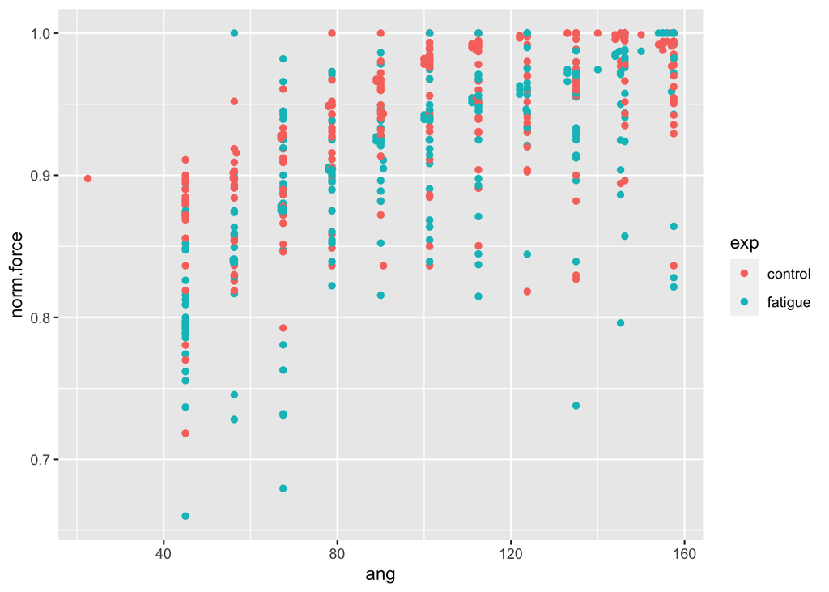

```r
data.joined%>%
  ggplot(aes(ang,norm.force,col=exp))+geom_point()
```

Here we are calculating the AIC scores and fitting the models.

```r
AICs <- data.joined%>%
  group_by(sub,exp)%>%
  summarize(
    m2=AICc(lm(norm.force~poly(ang,2))), #second order
    m3=AICc(lm(norm.force~poly(ang,3))), #third order
    m4=AICc(lm(norm.force~poly(ang,4))) #fourth order
  )%>%
  pivot_longer(m2:m4,names_to="model",values_to="AICc")%>%
  print()
```

```
## # A tibble: 165 × 4
## # Groups:   sub [28]
##    sub   exp     model    AICc
##    <chr> <chr>   <chr>   <dbl>
##  1 1     control m2    -130.
##  2 1     control m3    -126.
##  3 1     control m4    -117.
##  4 1     fatigue m2     -87.0
##  5 1     fatigue m3     -94.2
##  6 1     fatigue m4     -85.6
##  7 10    control m2     -70.1
##  8 10    control m3     -52.1
##  9 10    control m4       3.37
## 10 10    fatigue m2     -34.8
## # … with 155 more rows
```

```r
fits <- data.joined%>%
  group_by(sub,exp)%>%
  summarize(
    m2=predict(lm(norm.force~poly(ang,2)),newdata=data.frame(ang=x.pred)), #second order
    m3=predict(lm(norm.force~poly(ang,3)),newdata=data.frame(ang=x.pred)), #third order
    m4=predict(lm(norm.force~poly(ang,4)),newdata=data.frame(ang=x.pred)) #fourth order
  )%>%
  pivot_longer(m2:m4,names_to="model")%>%
  group_by(sub,exp,model)%>%
  summarize(theta_max=x.pred[which.max(value)])%>%
  print()
```

```
## # A tibble: 165 × 4
## # Groups:   sub, exp [55]
##    sub   exp     model theta_max
##    <chr> <chr>   <chr>     <dbl>
##  1 1     control m2         135.
##  2 1     control m3         135.
##  3 1     control m4         135.
##  4 1     fatigue m2         158.
##  5 1     fatigue m3         158.
##  6 1     fatigue m4         158.
##  7 10    control m2         136.
##  8 10    control m3         136.
##  9 10    control m4         136.
## 10 10    fatigue m2         158.
## # … with 155 more rows
```

```r
best.models <- fits%>%
  left_join(AICs)%>%
  group_by(sub,exp)%>%
  mutate(best=AICc==min(AICc))%>%
  filter(best==TRUE)%>%
  dplyr::select(-best)%>%
  print()
```

```
## # A tibble: 55 × 5
## # Groups:   sub, exp [55]
##    sub   exp     model theta_max   AICc
##    <chr> <chr>   <chr>     <dbl>  <dbl>
##  1 1     control m2         135. -130.
##  2 1     fatigue m3         158.  -94.2
##  3 10    control m2         136.  -70.1
##  4 10    fatigue m3         158.  -53.9
##  5 14    control m2         136. -115.
##  6 14    fatigue m3         158.  -75.6
##  7 17    control m2         158.  -38.5
##  8 17    fatigue m3         158.  -38.4
##  9 18    control m2         158.  -27.9
## 10 18    fatigue m2         139.  -29.3
## # … with 45 more rows
```

Performing an ANOVA to investigate whether a shift of theta max is different between the control and fatigue experiments.

```r
anova(lm(theta_max~exp,best.models))
```

```
## Analysis of Variance Table
##
## Response: theta_max
##           Df  Sum Sq Mean Sq F value  Pr(>F)
## exp        1   754.3  754.27   3.415 0.07019 .
## Residuals 53 11706.1  220.87
## ---
## Signif. codes:  0 '***' 0.001 '**' 0.01 '*' 0.05 '.' 0.1 ' ' 1
```

Calculating the mean shift with SEM.

```r
best.models%>%
  pivot_wider(id_cols=sub,names_from = exp,values_from=theta_max)%>%
  mutate(shift=fatigue-control)%>%
  ungroup()%>%
  summarize(mean.shift=abs(mean(na.rm=TRUE,shift)),se.shift=sd(na.rm=TRUE,shift)/sqrt(length(shift)))
```

```
## # A tibble: 1 × 2
##   mean.shift se.shift
##        <dbl>    <dbl>
## 1       8.02     4.33
```

#### There is a 8 degree shift in the mean of theta max between the control and fatigue conditions.

# Discussion

Actin-myosin overlap and maximal isometric force of a sarcomere are directly related. In Maganaris (2001), the transition from 30° of dorsiflexion to 45° of plantarflexion showed the human soleus (SOL) muscle fiber length decreased from 3.8 to 2.4 centimeters and consequently its force decreased from 3330 all the way down to 290 Newtons. Over the same range of angles, the tibialis anterior (TA) muscle fiber length increased from 3.7 to 6.0 centimeters and its force increased from 157 to 644 Newtons. These results indicated that the human SOL and TA muscles operate in an ascending limb and plateau of a typical FL relationship.

A graph of the force-length relationship is typically a parabola. The center of the parabola indicates the maximum force that is generated. Therefore, in a range of angles from 45 degrees to 157 degrees, 100 degrees is expected to generate the maximum force. It is also expected that force will increase from 45 to 100 degrees and then decrease from 100 to 157 degrees. The class-wide force-angle data did not show a typical FL relationship for both the control and fatigue group. The max force is around 145 for control, and there is very little decrease from the maximum until 157 degrees. The max force for fatigue was at 157 degrees and this group had no decrease. There was a very slight plateau from 110-140 but then the graph increased again.

# Author Contributions

All authors were involved in data collection. Clare Mungovan: worked with Julie on Methods and Discussion. Adam Qu: worked on the Introduction and made general edits. Matteo Torquati: worked on the Results section. Julie Vu: worked with Clare on Methods and Discussion

## CPK comments

Excellent work. Great job putting the code together to model the shifts. And you found one!! Your discussion is great, too.

My only criticism is that tables should be formatted (e.g., with `kable`) and they need a caption above them. (-2)

72/75

# References

Libretexts. 2020. “9.3a: Force of Muscle Contraction.” *Medicine LibreTexts*, August. https://med.libretexts.org/Bookshelves/Anatomy_and_Physiology/Book%3A_Anatomy_and_Physiology_%28Boundless%29/9%3A_Muscular_System/9.3%3A_Control_of_Muscle_Tension/9.3A%3A_Force_of_Muscle_Contraction.

Maganaris, C. N. 2001. “Force–Length Characteristics of in Vivo Human Skeletal Muscle.” *Acta Physiologica Scandinavica* 172 (4): 279–85. https://doi.org/https://doi.org/10.1046/j.1365-201x.2001.00799.x.

Muanjai, Pornpimol, Mantas Mickevicius, Audrius Sniečkus, Saulė Sipavičienė, Danguole Satkunskiene, Sigitas Kamandulis, and David A. Jones. 2020. “Low Frequency Fatigue and Changes in Muscle Fascicle Length Following Eccentric Exercise of the Knee Extensors.” *Experimental Physiology* 105 (3): 502–10.

Sharma, Hanjabam Barun, Arani Das, Prashant Tayade, and Kishore K. Deepak. 2021. “Recording of Length-Tension Relationship of Elbow Flexors and Extensors by Varying Elbow Angle in Human.” *Indian Journal of Physiology and Pharmacology*, January. https://ijpp.com/recording-of-length-tension-relationship-of-elbow-flexors-and-extensors-by-varying-elbow-angle-in-human/.